# Probit Regression in R, Python, Stata, and SAS

Roya Talibova, Bo Qu, Jiehui Ding, Shi Lan

2018/11/26

The purpose of this tutorial is to provide a basic understanding of Probit Regression and its implementation in R, Python, Stata, and SAS, using the “Female Labor Force Participation” data set.

## Model Introduction

A probit regression is a version of the generalized linear model used to model dichotomous outcome variables. It uses the inverse standard normal distribution as a linear combination of the predictors. The binary outcome variable Y is assumed to have a Bernoulli distribution with parameter p (where the success probability is $p \in (0,1)$). Hence, the probit link function is
$$probit(EY) = \Phi^{-1}(p_i) = \Phi^{-1}(P_i[Y=1]) = \sum_{k=0}^{k=n}\beta_kx_{ik}$$
where
$$\Phi=\frac{1}{\sqrt{2\pi}} \int_{-\infty}^{\alpha+\beta X} exp(-\frac{1}{2}Z^2)dZ$$
.

## Dataset: Female Labor Participation

In this tutorial, we work on Mroz data set on female labor participation with 8 variables. The data covers a sample of 753 married white women aged between 30 and 60 collected in 1975. The original source for this data is Mroz, T.A. (1987). “[The sensitivity of an empirical model of married women’s hours of work to economic and statistical assumptions](http://unionstats.gsu.edu/9220/Mroz_Econometrica_LaborSupply_1987.pdf).” *Econometrica* 55, 765-799. The subset of the original data set used in this study can be found [here](https://vincentarelbundock.github.io/Rdatasets/datasets.html). The description of the variables can be found below.

| Variable(s) | Description | Type |
| --- | --- | --- |
| lfp | Labor-force participation of the married white woman | Categorical: 0/1 |
| k5 | Number of children younger than 6 years old | Positive integer |
| k618 | Number of children aged 6-18 | Positive integer |
| age | Age in years | Positive integer |
| wc | Wife`s college attendance | Categorical: 0/1 |
| hc | Husband`s college attendance | Categorical: 0/1 |
| lwg | Log expected wage rate for women in the labor force | Numerical |
| inc | Family income without the wife`s income | Numerical |

The goal of the tutorial is to identify whether certain characteristics of a woman’s household and personal life can predict her labor-force participation.

## Languages

### R

#### 1. Data Summary

First, we load data into R by using read.csv given that the data is in a comma-separated format.

```r
mroz = read.csv('https://vincentarelbundock.github.io/Rdatasets/csv/carData/Mroz.csv')
```

This is what the first six rows look like in R:

```r
head(mroz)
```

```
##   X lfp k5 k618 age  wc hc       lwg    inc
## 1 1 yes  1    0  32  no no 1.2101647 10.910
## 2 2 yes  0    2  30  no no 0.3285041 19.500
## 3 3 yes  1    3  35  no no 1.5141279 12.040
## 4 4 yes  0    3  34  no no 0.0921151  6.800
## 5 5 yes  1    2  31 yes no 1.5242802 20.100
## 6 6 yes  0    0  54  no no 1.5564855  9.859
```

Then, we change all binary variables to be numeric.

```r
mroz$lfp = ifelse(mroz$lfp=="yes", 1, 0)
mroz$wc = ifelse(mroz$wc=="yes", 1, 0)
mroz$hc = ifelse(mroz$hc=="yes", 1, 0)
```

Here is the quick summary of the data.

```r
summary(mroz)
```

```
##        X            lfp               k5              k618
##  Min.   :  1   Min.   :0.0000   Min.   :0.0000   Min.   :0.000
##  1st Qu.:189   1st Qu.:0.0000   1st Qu.:0.0000   1st Qu.:0.000
##  Median :377   Median :1.0000   Median :0.0000   Median :1.000
##  Mean   :377   Mean   :0.5684   Mean   :0.2377   Mean   :1.353
##  3rd Qu.:565   3rd Qu.:1.0000   3rd Qu.:0.0000   3rd Qu.:2.000
##  Max.   :753   Max.   :1.0000   Max.   :3.0000   Max.   :8.000
##       age              wc               hc              lwg
##  Min.   :30.00   Min.   :0.0000   Min.   :0.0000   Min.   :-2.0541
##  1st Qu.:36.00   1st Qu.:0.0000   1st Qu.:0.0000   1st Qu.: 0.8181
##  Median :43.00   Median :0.0000   Median :0.0000   Median : 1.0684
##  Mean   :42.54   Mean   :0.2815   Mean   :0.3918   Mean   : 1.0971
##  3rd Qu.:49.00   3rd Qu.:1.0000   3rd Qu.:1.0000   3rd Qu.: 1.3997
##  Max.   :60.00   Max.   :1.0000   Max.   :1.0000   Max.   : 3.2189
##       inc
##  Min.   :-0.029
##  1st Qu.:13.025
##  Median :17.700
##  Mean   :20.129
##  3rd Qu.:24.466
##  Max.   :96.000
```

#### 2. Fitting model by Probit Regression

Next, we run a probit regression using lfp as a response variable and all the remaining variables as predictors.

```r
mroz.probit <- glm(lfp ~ k5 + k618 + age + wc + hc + lwg + inc,
                  data = mroz,
                  family = binomial(link = "probit"))
summary(mroz.probit)
```

```
##
## Call:
## glm(formula = lfp ~ k5 + k618 + age + wc + hc + lwg + inc, family = binomial(link = "probit"),
##     data = mroz)
##
## Deviance Residuals:
##     Min       1Q   Median       3Q      Max
## -2.1359  -1.1024   0.5967   0.9746   2.2236
##
## Coefficients:
##              Estimate Std. Error z value Pr(>|z|)
## (Intercept)  1.918418   0.382356   5.017 5.24e-07 ***
## k5          -0.874712   0.114423  -7.645 2.10e-14 ***
## k618        -0.038595   0.040950  -0.942 0.345942
## age         -0.037824   0.007605  -4.973 6.58e-07 ***
## wc           0.488310   0.136731   3.571 0.000355 ***
## hc           0.057172   0.124207   0.460 0.645306
## lwg          0.365635   0.089992   4.063 4.85e-05 ***
## inc         -0.020525   0.004852  -4.230 2.34e-05 ***
## ---
## Signif. codes:  0 '***' 0.001 '**' 0.01 '*' 0.05 '.' 0.1 ' ' 1
##
## (Dispersion parameter for binomial family taken to be 1)
##
##     Null deviance: 1029.75  on 752  degrees of freedom
## Residual deviance:  905.39  on 745  degrees of freedom
## AIC: 921.39
##
## Number of Fisher Scoring iterations: 4
```

All of the coefficients, except for k618 and hc, are statistically significant.

We can also obtain confidence intervals for the coefficient estimates.

```r
confint(mroz.probit)
```

```
##                   2.5 %      97.5 %
## (Intercept)  1.17740788  2.66999634
## k5          -1.10050075 -0.65525817
## k618        -0.11806899  0.04069610
## age         -0.05283742 -0.02300114
## wc           0.22421495  0.75547759
## hc          -0.18586158  0.30035566
## lwg          0.19375227  0.53805204
## inc         -0.02999733 -0.01126605
```

#### 3. Marginal effect

We first make a cross-tab of categorical predictors with our binary response variable and calculate adjusted predictions of lfp for two levels of hc and wc variables.

##### Group by hc

We start by tabulating lfp and hc.

```r
addmargins(table(mroz$lfp, mroz$hc, deparse.level=2))
```

```
##         mroz$hc
## mroz$lfp   0   1 Sum
##      0   207 118 325
##      1   251 177 428
##      Sum 458 295 753
```

Then, we calculate the adjusted predictions of lfp for the two levels of hc variable.

```r
hc_data0 = data.frame(k5 = mean(mroz$k5), k618 = mean(mroz$k618), age=mean(mroz$age),
                      lwg= mean(mroz$lwg), inc=mean(mroz$inc), hc=0, wc=mean(mroz$wc))
hc_data1 = data.frame(k5 = mean(mroz$k5), k618 = mean(mroz$k618), age=mean(mroz$age),
                      lwg= mean(mroz$lwg), inc=mean(mroz$inc), hc=1, wc=mean(mroz$wc))

h0 = predict(mroz.probit, hc_data0, type="response", se=TRUE)
h1 = predict(mroz.probit, hc_data1, type="response", se=TRUE)

hc_fit = data.frame(Margin = c(h0$fit[1], h1$fit[1]), se=c(h0$se.fit[1], h1$se.fit[1]))
hc_fit
```

```
##      Margin         se
## 1 0.5693807 0.02726260
## 2 0.5917191 0.03463592
```

The marginal probability of husband being a college graduate is is 0.59, while the marginal probability of husband being a high school graduate is slightly lower at 0.57.

##### Group by wc

Here is the tabulation of lfp and wc. As can be seen below, there is a significant imbalance between labor force participation, when the women are college graduates.

```r
addmargins(table(mroz$lfp, mroz$wc, deparse.level=2))
```

```
##         mroz$wc
## mroz$lfp   0   1 Sum
##      0   257  68 325
##      1   284 144 428
##      Sum 541 212 753
```

We also calculate the adjusted predictions of lfp for the two levels of wc variable, while keeping other variables at mean.

```r
wc_data0 = data.frame(k5 = mean(mroz$k5), k618 = mean(mroz$k618), age=mean(mroz$age),
                      lwg= mean(mroz$lwg), inc=mean(mroz$inc), hc = mean(mroz$hc), wc=0)
wc_data1 = data.frame(k5 = mean(mroz$k5), k618 = mean(mroz$k618), age=mean(mroz$age),
                      lwg= mean(mroz$lwg), inc=mean(mroz$inc), hc = mean(mroz$hc), wc=1)

w0 = predict(mroz.probit, wc_data0, type="response", se=TRUE)
w1 = predict(mroz.probit, wc_data1, type="response", se=TRUE)

wc_fit = data.frame(Margin = c(w0$fit[1], w1$fit[1]), se=c(w0$se.fit[1], w1$se.fit[1]))
wc_fit
```

```
##      Margin         se
## 1 0.5238094 0.02402095
## 2 0.7081631 0.03847631
```

The marginal probability increases from 0.524 to 0.708 when women are college graduates vs. only high-school graduates.

##### Group by age and wc

We can predict the outcome variable by both age and women’s college education. We will use increments of 10 between 30 and 60 as representative ages. As the results show, the older a woman gets, the less are her chances of participating in the labor force. Regardless of age, women’s college education always yields a higher probability of labor force participation.

```r
wc_data0_age=data.frame(k5=rep(mean(mroz$k5), 4), k618=rep(mean(mroz$k618), 4),
                        age=c(30, 40, 50, 60), lwg=rep(mean(mroz$lwg), 4),
                        inc=rep(mean(mroz$inc), 4), wc=rep(0, 4),
                        hc=rep(mean(mroz$hc), 4))

wc_data1_age=data.frame(k5=rep(mean(mroz$k5), 4), k618=rep(mean(mroz$k618), 4),
                        age=c(30, 40, 50, 60), lwg=rep(mean(mroz$lwg), 4),
                        inc=rep(mean(mroz$inc), 4), wc=rep(1, 4),
                        hc=rep(mean(mroz$hc), 4))

m0=predict(mroz.probit, wc_data0_age, type="response", se=TRUE)
m1=predict(mroz.probit, wc_data1_age, type="response", se=TRUE)

wc_fit_age = data.frame(Age=c(30, 40, 50, 60),Margin_wc0=m0$fit, Margin_wc1=m1$fit, se_wc0=m0$se.fit, se_wc1=m1$se.fit)
wc_fit_age
```

```
##   Age Margin_wc0 Margin_wc1     se_wc0     se_wc1
## 1  30  0.7033092  0.8466691 0.03936089 0.03561642
## 2  40  0.5618680  0.7402177 0.02509639 0.03716213
## 3  50  0.4119514  0.6047963 0.03193009 0.04744612
## 4  60  0.2739989  0.4552319 0.04823869 0.06726396
```

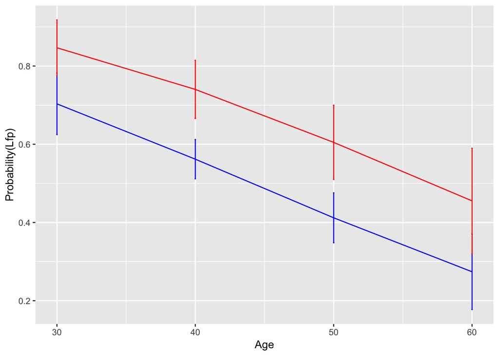

```r
ggplot(data=wc_fit_age,aes(y=Age)) +
geom_line(aes( x= Margin_wc0), colour="blue") +
geom_errorbarh(aes(xmin=Margin_wc0-2*se_wc0, xmax=Margin_wc0+2*se_wc0), height=.1,colour="blue")+
geom_line(aes(x = Margin_wc1), colour="red")+
geom_errorbarh(aes(xmin=Margin_wc1-2*se_wc1, xmax=Margin_wc1+2*se_wc1),
               height=.1,colour="red")+scale_color_manual(labels = c("wc=0","wc=1"), values = c("blue", "red"))+
coord_flip()+xlab('Probability(Lfp)') +
  ylab("Age")
```

##### Group by k5

Below is a cross-tab of lfp with k5. The tabulation shows that the more the number of kids aged below 6 years, the less women participate in the labor force.

```r
addmargins(table(mroz$lfp, mroz$k5, deparse.level=2))
```

```
##         mroz$k5
## mroz$lfp   0   1   2   3 Sum
##      0   231  72  19   3 325
##      1   375  46   7   0 428
##      Sum 606 118  26   3 753
```

We can predict lfp at different levels of k5, by keeping other variables at mean. When k5=0, the marginal probability of a woman’s participation in the labor force is 0.657, whereas when they have three or more, the probability is at around 0.013. This range is a good indicator of the significance of k5 variable.

```r
k_data=data.frame(k5=c(0,1,2,3),
                  k618=rep(mean(mroz$k618), 4), age=rep(mean(mroz$age), 4),
                  lwg=rep(mean(mroz$lwg), 4), inc=rep(mean(mroz$inc), 4),
                  wc = rep(mean(mroz$wc), 4), hc=rep(mean(mroz$hc), 4))

k0=predict(mroz.probit, k_data, type="response", se=TRUE)

k_fit = data.frame(k5=c(0,1,2,3),Margin_k=k0$fit, se_k=k0$se.fit)
k_fit
```

```
##   k5   Margin_k       se_k
## 1  0 0.65730850 0.02052209
## 2  1 0.31932620 0.03563207
## 3  2 0.08942632 0.03349808
## 4  3 0.01324307 0.01087202
```

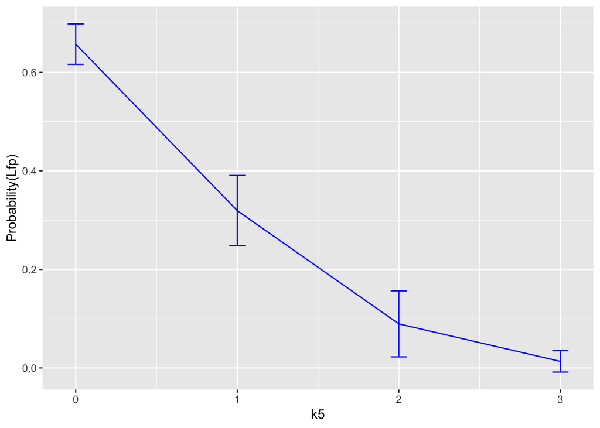

```r
ggplot(data=k_fit,aes(y=k5)) +
geom_line(aes( x= Margin_k), colour="blue") +
geom_errorbarh(aes(xmin=Margin_k-2*se_k, xmax=Margin_k+2*se_k), height=.1,colour="blue")+
coord_flip()+xlab('Probability(Lfp)') +
  ylab("k5")
```

### Python

#### Data Summary

First we start by loading the data into memory using the pandas package. The data is read in as a pandas dataframe, which is very similar to a R dataframe.

We also load numpy for array manipulation and we will be using the statsmodel package for Probit regression.

```
import pandas as pd
import numpy as np
from statsmodels.discrete.discrete_model import Probit
data = pd.read_csv('https://vincentarelbundock.github.io/Rdatasets/csv/carData/Mroz.csv')
```

To print the first few rows of the data, we use the head function. This is similar to other languages such as R.

```
print(data.head())
```

```
   Unnamed: 0  lfp  k5  k618  age   wc  hc       lwg        inc
0           1  yes   1     0   32   no  no  1.210165  10.910001
1           2  yes   0     2   30   no  no  0.328504  19.500000
2           3  yes   1     3   35   no  no  1.514128  12.039999
3           4  yes   0     3   34   no  no  0.092115   6.800000
4           5  yes   1     2   31  yes  no  1.524280  20.100000
```

#### Data Cleaning

Since some of the data is read in as strings, we need to transform them into binary categorical data using the following code. We also drop the first column as it is read in with row numbers, which we do not need.

```
data = data.drop(data.columns[0], axis = 1)
data["lfp"] = data["lfp"] == "yes"
data["wc"] = data["wc"] == "yes"
data["hc"] = data["hc"] == "yes"
```

Looking at the data again we see:

```
    lfp  k5  k618  age     wc     hc       lwg        inc
0  True   1     0   32  False  False  1.210165  10.910001
1  True   0     2   30  False  False  0.328504  19.500000
2  True   1     3   35  False  False  1.514128  12.039999
3  True   0     3   34  False  False  0.092115   6.800000
4  True   1     2   31   True  False  1.524280  20.100000
```

#### Summary Statistics

Before we begin our analysis here is a quick summary of the data. We use the function describe on our dataframe to generate some summary statistics.

```
print(data.describe())
```

This generates summary statistics for the continuous variables in our dataset.

```
               k5        k618         age         lwg         inc
count  753.000000  753.000000  753.000000  753.000000  753.000000
mean     0.237716    1.353254   42.537849    1.097115   20.128965
std      0.523959    1.319874    8.072574    0.587556   11.634799
min      0.000000    0.000000   30.000000   -2.054124   -0.029000
25%      0.000000    0.000000   36.000000    0.818086   13.025000
50%      0.000000    1.000000   43.000000    1.068403   17.700001
75%      0.000000    2.000000   49.000000    1.399717   24.466000
max      3.000000    8.000000   60.000000    3.218876   96.000000
```

#### Fitting Probit Regression

First we break our dataset into response variable and predictor variables. We will use lfp as our response variable and all the remaining variable as predictors. Then we use the statsmodels function to fit our Probit regression with our response variable and design matrix. The statsmodels package is unique from other languages and packages as it does not include an intercept term by default. This needs to be manually set.

```
Y = data["lfp"]
X = data.drop(["lfp"], 1)
X = sm.add_constant(X)
model = Probit(Y, X.astype(float))
probit_model = model.fit()
print(probit_model.summary())
```

The following is the results of our regression. The statsmodels package automatically includes p values and confidence intervals for each coefficient. For those that are familiar with objects, the probit model is stored as a probit model object in Python. All operations with the model are invoked as model.member_function().

```
Optimization terminated successfully.
         Current function value: 0.601189
         Iterations 5
                          Probit Regression Results
==============================================================================
Dep. Variable:                    lfp   No. Observations:                  753
Model:                         Probit   Df Residuals:                      745
Method:                           MLE   Df Model:                            7
Date:                Fri, 07 Dec 2018   Pseudo R-squ.:                  0.1208
Time:                        01:40:27   Log-Likelihood:                -452.69
converged:                       True   LL-Null:                       -514.87
                                        LLR p-value:                 9.471e-24
==============================================================================
                 coef    std err          z      P>|z|      [0.025      0.975]
------------------------------------------------------------------------------
const          1.9184      0.381      5.040      0.000       1.172       2.664
k5            -0.8747      0.114     -7.703      0.000      -1.097      -0.652
k618          -0.0386      0.040     -0.953      0.340      -0.118       0.041
age           -0.0378      0.008     -4.971      0.000      -0.053      -0.023
wc             0.4883      0.135      3.604      0.000       0.223       0.754
hc             0.0572      0.124      0.461      0.645      -0.186       0.300
lwg            0.3656      0.088      4.165      0.000       0.194       0.538
inc           -0.0205      0.005     -4.297      0.000      -0.030      -0.011
==============================================================================
```

It appears that all our predictors are statistically significant at level a except hc and k618.